# Assignment 3 - Non-Thresholded Gene set Enrichment Analysis

Joelle Jee

## Recap of Assignment 1 & 2

Publication Title: Disruption of the MBD2-NuRD complex but not MBD3-NuRD induces high level HbF expression in human adult erythroid cells  
Publication Date: 2019 Dec  
Publication Journal: Haematologica  
GEOID: GSE121992  
This study was able to prove that the Nucleosome Remodeling and Deacetylase complex member MBD2 knock-out in primary human erythroid cells were able to significantly elevate the gamma/gamma+beta mRNA expresssion of HbF, which is known in the literature to benefit sickle cell anemia patients.  
They performed RNA-sequencing of the MBD2KO and the control (sgCSR) cells before and after differentiation to measure the effect of deficiency of MBD in erythroid differentiation.  
They found that MBD2KO in primary human erythroid cells significantly elevate the gamma/gamma+beta mRNA expresssion of HbF without changing the morphological appearance after differentiation compared to controls. From this finding, the authors proposed that therapies targeting MBD2 can ameliorate the underlying pathophysiological defects in sickle cell anemia and beta (beta)-thalassemia.  
In assignment 1, the dataset was cleaned by removing outliers, and non-informative datapoints, and mapped to HUGO gene symbols, and normalized using Timmed Mean of M-Values. In this assignment, the genes will be ranked according to differential expression and I will perform enrichment analysis to see the dominant themes in the top hits. From the results, I will determine if my study supports the original finding that the MBD2KO does not have adverse effects on erythroid cell differentiation.  
In assignment 2, the normalized expression data that was created in Assignment #1 was ranked according to differential expression. Then, thresholded over-representation analysis was performed on this data to highlight dominant themes in your top set of genes.  
In this assignment, I will perform a non-thresholded gene set enrichment analysis, and compared the resutls from assignment 2.

## Data/Platform Overview

**Title of Platform:** Illumina HiSeq 2500 (Homo sapiens) **Submission Date:** Mar 14 2013 **Last Update Date:** Mar 27 2019 **Organism:** Homo sapiens **Number of GEO datasets using this study:** 6080 **NUmber of GEO samples using this study:** 167630

## Non-thresholded enrichment analysis with GSEA

### Parse the ranked list of genes into .rnk format

GSEA was used for enrichment analysis because GSEAPrerank runs enrichment analysis on user-supplied, ranked list of genes.<sup>2</sup> We just input the ranked list from Assignment 2.  
Here is a quick look of the data:\

```r
ranked_pre <- read.table("data/ranked_MBD2KO_pre.txt")
knitr::kable(ranked_pre[1:10,], "html",
             caption = "ranked list for MBD2KO_pre from A2")
```

ranked list for MBD2KO_pre from A2

|  | logFC | logCPM | F | PValue | FDR | rank |
| --- | --- | --- | --- | --- | --- | --- |
| SCN2A | -3.615769 | 5.387620 | 1278.4693 | 0 | 0 | -12.67136 |
| RYR3 | -3.438897 | 5.806881 | 1167.4480 | 0 | 0 | -12.44063 |
| TRIM10 | 5.616928 | 4.913124 | 1124.5352 | 0 | 0 | 12.34557 |
| SLC4A1 | 5.572297 | 6.031449 | 959.8642 | 0 | 0 | 11.94405 |
| HPGD | -2.681145 | 8.478380 | 918.5732 | 0 | 0 | -11.83267 |
| ZNF521 | -2.384001 | 6.922638 | 804.3091 | 0 | 0 | -11.49654 |
| MS4A2 | -6.161769 | 5.329335 | 674.6235 | 0 | 0 | -11.05257 |
| VWA5A | -2.386240 | 6.267088 | 551.6287 | 0 | 0 | -10.54586 |
| MCF2 | -3.960830 | 3.917930 | 539.2199 | 0 | 0 | -10.48871 |
| ID4 | -7.233315 | 3.680654 | 535.1501 | 0 | 0 | -10.46968 |

```r
ranked_post <- read.table("data/ranked_MBD2KO_post.txt")
knitr::kable(ranked_post[1:10,], "html",
             caption = "ranked list for MBD2KO_post from A2")
```

ranked list for MBD2KO_post from A2

|  | logFC | logCPM | F | PValue | FDR | rank |
| --- | --- | --- | --- | --- | --- | --- |
| TRIM10 | 4.617047 | 7.045367 | 3154.356 | 0 | 0 | 17.81304 |
| AHNAK | -2.656560 | 8.021342 | 1672.688 | 0 | 0 | -15.80429 |
| MYO18B | 6.793160 | 4.582680 | 1669.748 | 0 | 0 | 15.79873 |
| SLC4A1 | 4.182659 | 9.106400 | 1454.964 | 0 | 0 | 15.36390 |
| CPEB4 | 2.280855 | 7.534594 | 1385.063 | 0 | 0 | 15.20855 |
| SLC2A1 | 2.555287 | 8.497969 | 1320.443 | 0 | 0 | 15.05787 |
| DST | 2.150546 | 7.344163 | 1317.672 | 0 | 0 | 15.05125 |
| RORA | 2.541799 | 6.377443 | 1060.065 | 0 | 0 | 14.36619 |
| ELMO1 | -2.768613 | 6.006154 | 1030.766 | 0 | 0 | -14.27806 |
| GRAP2 | 2.897287 | 5.418249 | 1025.058 | 0 | 0 | 14.26060 |

Now we had to parse the file in an .rnk format to input to GSEA. It was saved in the data folder.

```r
pre <- data.frame("GeneName" = rownames(ranked_pre),
                  "rank" = ranked_pre$rank)

write.table(pre,
            file=file.path("data","MBD2KO_pre.rnk.txt"),sep = "\t",
            row.names = FALSE,col.names = TRUE,quote = FALSE, eol = "\n")

post <- data.frame("GeneName" = rownames(ranked_post),
                  "rank" = ranked_post$rank)
write.table(post,
            file=file.path("data","MBD2KO_post.rnk.txt"),sep = "\t",
            row.names = FALSE,col.names = TRUE,quote = FALSE, eol = "\n")
```

```r
knitr::kable(pre[1:10,], "html", caption = "ranked list for MBD2KO_pre in .rnk format")
```

ranked list for MBD2KO_pre in .rnk format

| GeneName | rank |
| --- | --- |
| SCN2A | -12.67136 |
| RYR3 | -12.44063 |
| TRIM10 | 12.34557 |
| SLC4A1 | 11.94405 |
| HPGD | -11.83267 |
| ZNF521 | -11.49654 |
| MS4A2 | -11.05257 |
| VWA5A | -10.54586 |
| MCF2 | -10.48871 |
| ID4 | -10.46968 |

```r
knitr::kable(post[1:10,], "html", caption = "ranked list for MBD2KO_post in .rnk format")
```

ranked list for MBD2KO_post in .rnk format

| GeneName | rank |
| --- | --- |
| TRIM10 | 17.81304 |
| AHNAK | -15.80429 |
| MYO18B | 15.79873 |
| SLC4A1 | 15.36390 |
| CPEB4 | 15.20855 |
| SLC2A1 | 15.05787 |
| DST | 15.05125 |
| RORA | 14.36619 |
| ELMO1 | -14.27806 |
| GRAP2 | 14.26060 |

### Run GSEAPrerank

The above datasets were uploaded to the GSEA software

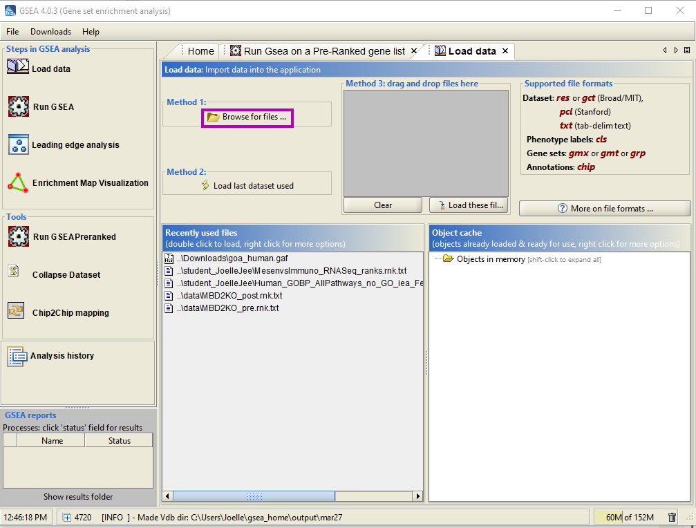

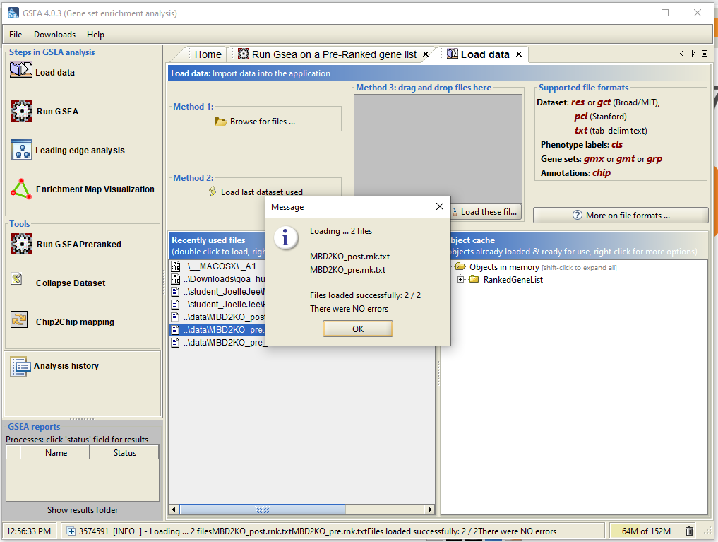

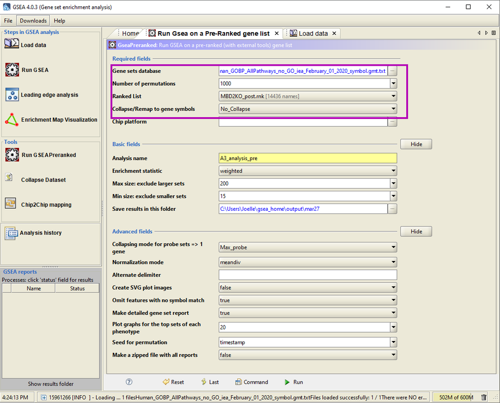

The results were saved in /Users/Joelle/gsea_home/output folder. We will be loading the .gmt file with package qusage.<sup>3</sup>

```r
if (!requireNamespace("BiocManager", quietly = TRUE))
    install.packages("BiocManager")

if (!requireNamespace("qusage", quietly = TRUE))
    BiocManager::install("qusage")

# load the result as a large named list
post <- qusage::read.gmt("data/MBD2KO_post_non_thresh_result.gmt")

# get the first few rows and turn into data frame
summ_post <- data.frame("Ontology"  = unlist(lapply(names(post)[1:15],
                                                    function(x) {
                                                      unlist(strsplit(x,"%"))[1]})),
                        "Gene" = unlist(lapply(post[1:15],
                                        function(x) {
                                          paste(x, collapse = ", ")
                                        })))
# load the result as a large named list
pre <- qusage::read.gmt("data/MBD2KO_post_non_thresh_result.gmt")

summ_pre <- data.frame("Ontology"  = unlist(lapply(names(pre)[1:15],
                                                    function(x) {
                                                      unlist(strsplit(x,"%"))[1]})),
                        "Gene" = unlist(lapply(pre[1:15],
                                        function(x) {
                                          paste(x, collapse = ", ")
                                        })))
# getting rid of messy rownames
rownames(summ_post) <- c()
rownames(summ_post) <- c()

# Let's see how they look
knitr::kable(summ_post, "html", caption = "MBD2KO_post Enrichment Analysis Result")
```

MBD2KO_post Enrichment Analysis Result

| Ontology | Gene |
| --- | --- |
| REGULATION OF CD4-POSITIVE, ALPHA-BETA T CELL ACTIVATION | RUNX3, ZC3H12A, LGALS9, IL18, RARA, NCKAP1L, LGALS9B, CD274, ZBTB7B, TWSG1, ANXA1, CD80, LOXL3, AGER, SOCS1, SOCS5, CD55, NFKBID, NFKBIZ, CD160, HMGB1, MALT1, RUNX1, MYB, RC3H1, RC3H2, CBFB, TGFBR2, P… |
| TRNA METABOLIC PROCESS | TYW3, THG1L, CARS2, LARS2, EXOSC7, CSTF2, EXOSC9, GTF3C1, EXOSC8, TSEN54, GTF3C2, EXOSC2, VARS2, GTF3C3, SLFN13, GTF3C4, GTF3C5, GTF3C6, NSUN6, EEF1E1, IARS2, C2orf49, RTCB, DPH3, BRF1, OSGEP, DARS2, … |
| SNRNP ASSEMBLY | NUP50, NUP35, NUP54, SNRPD2, SNRPD1, SNRPD3, NUP37, GEMIN2, PHAX, CLNS1A, GEMIN4, GEMIN5, GEMIN6, GEMIN7, GEMIN8, DDX20, SMN2, SMN1, SNUPN, SNRPG, SNRPE, SNRPF, WDR77, TGS1, SNRPB, NUP214, PRMT5, NUP2… |
| NON-CODING RNA METABOLISM | NUP50, NUP35, NUP54, SNRPD2, SNRPD1, SNRPD3, NUP37, GEMIN2, PHAX, CLNS1A, GEMIN4, GEMIN5, GEMIN6, GEMIN7, GEMIN8, DDX20, SMN2, SMN1, SNUPN, SNRPG, SNRPE, SNRPF, WDR77, TGS1, SNRPB, NUP214, PRMT5, NUP2… |
| POSITIVE REGULATION OF SPROUTING ANGIOGENESIS | HDAC7, GATA2, ITGA5, PKM, JAK1, MAP3K3, FGF2, PDPK1, JMJD8, TJP1, ANXA1, VEGFA, AGTR1, HMOX1, PIK3C2A, SMAD1, KLF4, S100A1, CIB1 |
| TRNA PROCESSING | NUP50, NUP35, NUP54, TRMT10C, ELAC2, TRNT1, NUP37, HSD17B10, POP5, POP7, CPSF4, POP1, POP4, TSEN54, ALKBH8, GTPBP3, TRMU, NSUN2, NSUN6, URM1, TRMT10A, ADAT1, TRMT1, ADAT2, TRMT6, TSEN2, THG1L, FTSJ1, … |
| RNA LOCALIZATION | MAGOH, UPF3B, THOC3, XPO1, THOC2, DKC1, THOC7, ARC, AGFG1, EIF6, WDR33, SRRM1, SLBP, TSC1, MRPL18, EXOSC2, YTHDC1, AAAS, FYTTD1, NOL6, XPOT, RRS1, TCP1, DDX19A, EIF5A, DDX19B, MCM3AP, U2AF1L4, NXF1, E… |
| PID_IL8_CXCR2_PATHWAY | ARRB1, PDPK1, GNB1, PPP2R1A, RAC2, VASP, ELMO1, DOCK2, RAB5A, RAB7A, PPP2CA, CBL, PLCB3, PIK3CG, PLCB2, PRKCB, PRKCA, GNAI2, GNA15, GNG2, RAB11A, CXCL8, ARRB2, AKT1, DNM1, LYN |
| POSITIVE REGULATION OF CD4-POSITIVE, ALPHA-BETA T CELL ACTIVATION | CD55, NFKBID, NFKBIZ, LGALS9, IL18, NCKAP1L, RARA, MALT1, ZBTB7B, MYB, ANXA1, CD80, TGFBR2, PRKCQ, CD81, SOCS1, SOCS5 |
| IL8- AND CXCR2-MEDIATED SIGNALING EVENTS | PRKCA, ARRB2, RAC2, DOCK2, RAB7A, CXCL8, CBL, ELMO1, PDPK1, PIK3CG, RAB5A, GNA15, LYN, PPP2CA, AKT1, DNM1, PLCB2, RAB11A, PPP2R1A, VASP, ARRB1, GNG2, GNAI2, PLCB3, GNB1, PRKCB |
| REGULATION OF MAST CELL ACTIVATION | C12orf4, ADGRE2, FES, PLSCR1, SPHK2, CD226, LGALS9, SNX4, FER, UNC13D, VAMP8, SNX6, GAB2, VAMP3, SYK, VAMP7, STXBP2, VAMP2, LYN, ENPP3, CD84 |
| PID_RAC1_REG_PATHWAY | ARHGEF7, MCF2, ARHGEF6, DEF6, ELMO1, DOCK2, SOS1, PREX1, DOCK6, RALBP1, RAP1GDS1, ARHGAP17, CHN1, TIAM2, SPATA13, ARHGEF2, ARHGAP9, TRIO, RACGAP1, CHN2, ABR, ABI1, RAC1, VAV1, EPS8, ARHGAP1, ARHGDIA, … |
| REGULATION OF RAC1 ACTIVITY | CHN1, DEF6, VAV1, TRIO, BCR, TIAM2, ARHGEF2, DOCK2, ABI1, SOS1, ELMO1, RACGAP1, VAV2, RAC1, DOCK6, VAV3, ARHGAP1, ARHGAP17, RALBP1, MCF2, SPATA13, ARHGEF7, ARHGEF6, ARHGAP9, RAP1GDS1, EPS8, ARHGDIA, A… |
| MYELOID LEUKOCYTE MIGRATION | PRTN3, NCKAP1L, AZU1, PIP5K1C, IL6R, CXCL8, TNFRSF11A, CD47, CKLF, ITGB2, JAM3, KIT, CXADR, ANXA1, SYK, P2RX4, ADGRE2, LGALS3, GBF1, PIK3CG, RPS19 |
| PRIMARY ALCOHOL METABOLIC PROCESS | GDPD1, NAPEPLD, AKR1B1, ALDH1A1, ACSS2, AKR1A1, PARK7, CACNA1H, CBR4, AKR1C2, ACSS1, AKR1C1, SULT2A1, AKR1C3, NAAA, ADH5, PECR, SULT1A2, CYP2D6, ALDH2, ALDH3A2, ALDH1B1, AKR7A2, SULT1A1, RETSAT, GDE1,… |

```r
knitr::kable(summ_pre, "html", caption = "MBD2KO_pre Enrichment Analysis Result")
```

|  | Ontology | Gene |
| --- | --- | --- |
| REGULATION OF CD4-POSITIVE, ALPHA-BETA T CELL ACTIVATION%GOBP%GO:2000514 | REGULATION OF CD4-POSITIVE, ALPHA-BETA T CELL ACTIVATION | RUNX3, ZC3H12A, LGALS9, IL18, RARA, NCKAP1L, LGALS9B, CD274, ZBTB7B, TWSG1, ANXA1, CD80, LOXL3, AGER, SOCS1, SOCS5, CD55, NFKBID, NFKBIZ, CD160, HMGB1, MALT1, RUNX1, MYB, RC3H1, RC3H2, CBFB, TGFBR2, P… |
| TRNA METABOLIC PROCESS%GOBP%GO:0006399 | TRNA METABOLIC PROCESS | TYW3, THG1L, CARS2, LARS2, EXOSC7, CSTF2, EXOSC9, GTF3C1, EXOSC8, TSEN54, GTF3C2, EXOSC2, VARS2, GTF3C3, SLFN13, GTF3C4, GTF3C5, GTF3C6, NSUN6, EEF1E1, IARS2, C2orf49, RTCB, DPH3, BRF1, OSGEP, DARS2, … |
| SNRNP ASSEMBLY%REACTOME DATABASE ID RELEASE 71%191859 | SNRNP ASSEMBLY | NUP50, NUP35, NUP54, SNRPD2, SNRPD1, SNRPD3, NUP37, GEMIN2, PHAX, CLNS1A, GEMIN4, GEMIN5, GEMIN6, GEMIN7, GEMIN8, DDX20, SMN2, SMN1, SNUPN, SNRPG, SNRPE, SNRPF, WDR77, TGS1, SNRPB, NUP214, PRMT5, NUP2… |
| NON-CODING RNA METABOLISM%REACTOME DATABASE ID RELEASE 71%194441 | NON-CODING RNA METABOLISM | NUP50, NUP35, NUP54, SNRPD2, SNRPD1, SNRPD3, NUP37, GEMIN2, PHAX, CLNS1A, GEMIN4, GEMIN5, GEMIN6, GEMIN7, GEMIN8, DDX20, SMN2, SMN1, SNUPN, SNRPG, SNRPE, SNRPF, WDR77, TGS1, SNRPB, NUP214, PRMT5, NUP2… |
| POSITIVE REGULATION OF SPROUTING ANGIOGENESIS%GOBP%GO:1903672 | POSITIVE REGULATION OF SPROUTING ANGIOGENESIS | HDAC7, GATA2, ITGA5, PKM, JAK1, MAP3K3, FGF2, PDPK1, JMJD8, TJP1, ANXA1, VEGFA, AGTR1, HMOX1, PIK3C2A, SMAD1, KLF4, S100A1, CIB1 |
| TRNA PROCESSING%REACTOME%R-HSA-72306.6 | TRNA PROCESSING | NUP50, NUP35, NUP54, TRMT10C, ELAC2, TRNT1, NUP37, HSD17B10, POP5, POP7, CPSF4, POP1, POP4, TSEN54, ALKBH8, GTPBP3, TRMU, NSUN2, NSUN6, URM1, TRMT10A, ADAT1, TRMT1, ADAT2, TRMT6, TSEN2, THG1L, FTSJ1, … |
| RNA LOCALIZATION%GOBP%GO:0006403 | RNA LOCALIZATION | MAGOH, UPF3B, THOC3, XPO1, THOC2, DKC1, THOC7, ARC, AGFG1, EIF6, WDR33, SRRM1, SLBP, TSC1, MRPL18, EXOSC2, YTHDC1, AAAS, FYTTD1, NOL6, XPOT, RRS1, TCP1, DDX19A, EIF5A, DDX19B, MCM3AP, U2AF1L4, NXF1, E… |
| PID_IL8_CXCR2_PATHWAY%MSIGDB_C2%PID_IL8_CXCR2_PATHWAY | PID_IL8_CXCR2_PATHWAY | ARRB1, PDPK1, GNB1, PPP2R1A, RAC2, VASP, ELMO1, DOCK2, RAB5A, RAB7A, PPP2CA, CBL, PLCB3, PIK3CG, PLCB2, PRKCB, PRKCA, GNAI2, GNA15, GNG2, RAB11A, CXCL8, ARRB2, AKT1, DNM1, LYN |
| POSITIVE REGULATION OF CD4-POSITIVE, ALPHA-BETA T CELL ACTIVATION%GOBP%GO:2000516 | POSITIVE REGULATION OF CD4-POSITIVE, ALPHA-BETA T CELL ACTIVATION | CD55, NFKBID, NFKBIZ, LGALS9, IL18, NCKAP1L, RARA, MALT1, ZBTB7B, MYB, ANXA1, CD80, TGFBR2, PRKCQ, CD81, SOCS1, SOCS5 |
| IL8- AND CXCR2-MEDIATED SIGNALING EVENTS%PATHWAY INTERACTION DATABASE NCI-NATURE CURATED DATA%IL8- AND CXCR2-MEDIATED SIGNALING EVENTS | IL8- AND CXCR2-MEDIATED SIGNALING EVENTS | PRKCA, ARRB2, RAC2, DOCK2, RAB7A, CXCL8, CBL, ELMO1, PDPK1, PIK3CG, RAB5A, GNA15, LYN, PPP2CA, AKT1, DNM1, PLCB2, RAB11A, PPP2R1A, VASP, ARRB1, GNG2, GNAI2, PLCB3, GNB1, PRKCB |
| REGULATION OF MAST CELL ACTIVATION%GOBP%GO:0033003 | REGULATION OF MAST CELL ACTIVATION | C12orf4, ADGRE2, FES, PLSCR1, SPHK2, CD226, LGALS9, SNX4, FER, UNC13D, VAMP8, SNX6, GAB2, VAMP3, SYK, VAMP7, STXBP2, VAMP2, LYN, ENPP3, CD84 |
| PID_RAC1_REG_PATHWAY%MSIGDB_C2%PID_RAC1_REG_PATHWAY | PID_RAC1_REG_PATHWAY | ARHGEF7, MCF2, ARHGEF6, DEF6, ELMO1, DOCK2, SOS1, PREX1, DOCK6, RALBP1, RAP1GDS1, ARHGAP17, CHN1, TIAM2, SPATA13, ARHGEF2, ARHGAP9, TRIO, RACGAP1, CHN2, ABR, ABI1, RAC1, VAV1, EPS8, ARHGAP1, ARHGDIA, … |
| REGULATION OF RAC1 ACTIVITY%PATHWAY INTERACTION DATABASE NCI-NATURE CURATED DATA%REGULATION OF RAC1 ACTIVITY | REGULATION OF RAC1 ACTIVITY | CHN1, DEF6, VAV1, TRIO, BCR, TIAM2, ARHGEF2, DOCK2, ABI1, SOS1, ELMO1, RACGAP1, VAV2, RAC1, DOCK6, VAV3, ARHGAP1, ARHGAP17, RALBP1, MCF2, SPATA13, ARHGEF7, ARHGEF6, ARHGAP9, RAP1GDS1, EPS8, ARHGDIA, A… |
| MYELOID LEUKOCYTE MIGRATION%GOBP%GO:0097529 | MYELOID LEUKOCYTE MIGRATION | PRTN3, NCKAP1L, AZU1, PIP5K1C, IL6R, CXCL8, TNFRSF11A, CD47, CKLF, ITGB2, JAM3, KIT, CXADR, ANXA1, SYK, P2RX4, ADGRE2, LGALS3, GBF1, PIK3CG, RPS19 |
| PRIMARY ALCOHOL METABOLIC PROCESS%GOBP%GO:0034308 | PRIMARY ALCOHOL METABOLIC PROCESS | GDPD1, NAPEPLD, AKR1B1, ALDH1A1, ACSS2, AKR1A1, PARK7, CACNA1H, CBR4, AKR1C2, ACSS1, AKR1C1, SULT2A1, AKR1C3, NAAA, ADH5, PECR, SULT1A2, CYP2D6, ALDH2, ALDH3A2, ALDH1B1, AKR7A2, SULT1A1, RETSAT, GDE1,… |

### Compare with Thresholded Gene Enrichment Analysis

Let’s compare the results from Assignment 2.

```r
# load enrichment result data from Assignment 2
A2_pre <- read.table("data/MBD2KO_pre_enrich.txt",
                     sep = "\t", header = TRUE)[, c(-5, -6)]  # get rid of unnecessary columns
A2_post <- read.table("data/MBD2KO_post_enrich.txt",
                      sep = "\t", header = TRUE)[, c(-5, -6)]

knitr::kable(A2_pre[1:15, ], "html", caption = "Thresholded Gene Enrichment Analysis of MBD2KO_pre")
```

Thresholded Gene Enrichment Analysis of MBD2KO_pre

| Term | Overlap | P.value | Adjusted.P.value | Odds.Ratio | Combined.Score | Genes |
| --- | --- | --- | --- | --- | --- | --- |
| regulation of mitotic cell cycle phase transition (GO:1901990) | 63/184 | 0.0000055 | 0.0280881 | 1.696266 | 20.54177 | CEP57;CEP164;KIF14;CDC14A;CDC20;PSMD8;PSMD2;PSMD3;CNTRL;PSMD1;CEP250;KNTC1;BTRC;CEP290;TMEM14B;CEP135;HAUS4;CSNK1D;TUBG1;DYNLL1;HAUS2;HAUS1;ZW10;CEP63;MAPRE1;UBA52;SFI1;SDCCAG8;PSMD11;ANAPC16;PSMD13;H… |
| neutrophil degranulation (GO:0043312) | 136/479 | 0.0000086 | 0.0218990 | 1.406613 | 16.40920 | CYFIP1;ATP8A1;GMFG;EPX;PYCARD;PNP;LAMP1;PSMD2;FTH1;PSMD3;LAMP2;PSMD1;CPNE3;ENPP4;NHLRC3;CYBA;SCAMP1;ATAD3B;RAB31;DOK3;ADAM8;PRTN3;SLC27A2;VCL;FTL;CFD;VCP;PSMD11;BRI3;PSMD13;MGST1;IQGAP1;IQGAP2;PLD1;C3… |
| neutrophil activation involved in immune response (GO:0002283) | 136/483 | 0.0000135 | 0.0229980 | 1.394964 | 15.63939 | CYFIP1;ATP8A1;GMFG;EPX;PYCARD;PNP;LAMP1;PSMD2;FTH1;PSMD3;LAMP2;PSMD1;CPNE3;ENPP4;NHLRC3;CYBA;SCAMP1;ATAD3B;RAB31;DOK3;ADAM8;PRTN3;SLC27A2;VCL;FTL;CFD;VCP;PSMD11;BRI3;PSMD13;MGST1;IQGAP1;IQGAP2;PLD1;C3… |
| neutrophil mediated immunity (GO:0002446) | 136/487 | 0.0000210 | 0.0268248 | 1.383506 | 14.89997 | CYFIP1;ATP8A1;GMFG;EPX;PYCARD;PNP;LAMP1;PSMD2;FTH1;PSMD3;LAMP2;PSMD1;CPNE3;ENPP4;NHLRC3;CYBA;SCAMP1;ATAD3B;RAB31;DOK3;ADAM8;PRTN3;SLC27A2;VCL;FTL;CFD;VCP;PSMD11;BRI3;PSMD13;MGST1;IQGAP1;IQGAP2;PLD1;C3… |
| cellular response to nutrient levels (GO:0031669) | 24/54 | 0.0000469 | 0.0478220 | 2.201855 | 21.94901 | PLEKHF2;SREBF1;HSPA8;RIPOR1;CDKN2B;BMPR2;RALB;USP33;LRRK2;AKR1C3;FOXO1;WRN;MAP1LC3A;RRAGC;STK24;STK26;LAMP2;RRAGD;ALB;PDK4;ULK1;GAS2L1;PDK2;FADS1 |
| long-chain fatty-acyl-CoA metabolic process (GO:0035336) | 14/25 | 0.0000838 | 0.0713001 | 2.774337 | 26.04182 | ELOVL1;HACD1;DGAT2;ELOVL5;ACSL1;ELOVL2;ACSL6;ACSL5;ACSL4;HSD17B12;HACD2;FAR1;ACSBG1;FAR2 |
| regulation of cell cycle G2/M phase transition (GO:1902749) | 32/84 | 0.0001149 | 0.0837917 | 1.887304 | 17.11992 | CEP57;CEP164;KIF14;HMMR;AURKA;PRKAR2B;CNTRL;CEP250;CEP192;PCNT;CEP290;CEP76;CEP78;CEP135;NDE1;MBD1;CEP152;HAUS4;CSNK1D;DYNLL1;TUBG1;HAUS2;HAUS1;NEDD1;CDK6;ALMS1;CEP63;CEP41;MAPRE1;ATF5;SFI1;SDCCAG8 |
| ciliary basal body-plasma membrane docking (GO:0097711) | 35/96 | 0.0001575 | 0.1004564 | 1.806209 | 15.81548 | CEP57;CEP164;PRKAR2B;TMEM67;CNTRL;TCTN1;CEP250;CEP192;PCNT;CEP290;CEP76;CEP78;CEP135;NDE1;MBD1;CEP152;RAB3IP;HAUS4;KIF24;CSNK1D;RPGRIP1L;TUBG1;DYNLL1;HAUS2;HAUS1;AHI1;NEDD1;ALMS1;CEP162;B9D1;CEP63;CEP… |
| regulation of erythrocyte differentiation (GO:0045646) | 16/32 | 0.0001587 | 0.0899959 | 2.477087 | 21.67042 | LYN;HSPA9;LDB1;PRMT1;ARNT;FOXO3;ACVR1B;MAPK14;GATA1;FAM210B;ZFP36;CDK6;TAL1;ZFPM1;HSPA1B;HSPA1A |
| long-chain fatty-acyl-CoA biosynthetic process (GO:0035338) | 11/18 | 0.0001723 | 0.0878992 | 3.027551 | 26.23846 | ELOVL1;HACD1;ELOVL5;ACSL1;ELOVL2;ACSL6;ACSL5;ACSL4;ACSBG1;HSD17B12;HACD2 |
| regulation of G2/M transition of mitotic cell cycle (GO:0010389) | 49/149 | 0.0001785 | 0.0828025 | 1.629225 | 14.06182 | CEP57;CEP164;KIF14;PSMD8;PSMD2;PSMD3;CNTRL;PSMD1;CEP250;CEP290;CEP135;HAUS4;CSNK1D;TUBG1;DYNLL1;HAUS2;HAUS1;RAD51B;RAD51C;CEP63;MAPRE1;UBA52;SFI1;SDCCAG8;PSMD11;PSMD13;VPS4B;HMMR;PSMB10;AURKA;PSMB6;PS… |
| protein glycosylation (GO:0006486) | 44/130 | 0.0001806 | 0.0768074 | 1.676797 | 14.45254 | ST6GALNAC1;POGLUT1;TUSC3;TNKS;CCDC126;GALNT18;MPI;POMT1;FUT1;ART4;SERP1;FUT9;MGAT5;ST3GAL4;ST8SIA4;MAN1C1;MGAT2;ST3GAL1;B3GALNT2;ALG1L2;GALNT6;ALG8;PARP4;ALG6;GALNT2;GALNT1;COG3;PMM2;B3GALT4;SIRT4;TET… |
| plasma membrane bounded cell projection assembly (GO:0120031) | 72/241 | 0.0002082 | 0.0817392 | 1.480085 | 12.54647 | SPAG16;CYFIP1;TTC26;CEP19;CEP164;FNBP1L;PTPDC1;CDC14A;RPGR;TBC1D32;TCTN1;TMEM107;ARFIP2;BBS9;IFT57;CEP290;BBS4;DYNC2H1;MKKS;CCDC113;KIF24;IFT80;EMP2;ANO6;DYNLL1;MTSS1;CD2AP;IFT88;IFT43;FAM161A;IFT81;K… |
| chaperone mediated protein folding requiring cofactor (GO:0051085) | 13/24 | 0.0002366 | 0.0862324 | 2.683511 | 22.40527 | HSPA9;ERO1A;HSPA8;HSPA5;HSPA1L;HSPA4L;DNAJB14;HSPA2;GAK;BAG1;HYOU1;HSPA1B;HSPA1A |
| Wnt signaling pathway, calcium modulating pathway (GO:0007223) | 17/36 | 0.0002416 | 0.0821762 | 2.339471 | 19.48410 | FZD3;FZD5;FZD4;FZD6;NFATC1;NLK;TNRC6C;PPP3CA;GNG2;AGO3;AGO4;AGO2;CTNNB1;PDE6B;PDE6A;CALM1;PLCB2 |

```r
knitr::kable(A2_post[1:15, ], "html", caption = "Thresholded Gene Enrichment Analysis of MBD2KO_post")
```

Thresholded Gene Enrichment Analysis of MBD2KO_post

| GO_Biological_Process_2018.Term | GO_Biological_Process_2018.Overlap | GO_Biological_Process_2018.P.value | GO_Biological_Process_2018.Adjusted.P.value | GO_Biological_Process_2018.Odds.Ratio | GO_Biological_Process_2018.Combined.Score | GO_Biological_Process_2018.Genes |
| --- | --- | --- | --- | --- | --- | --- |
| ribosome biogenesis (GO:0042254) | 143/226 | 0e+00 | 0.0000000 | 1.651425 | 52.01536 | LTV1;RPL5;RPL30;RPL3;RPL31;POP4;RPP30;RRP1;RPL8;NOC2L;RPL6;RPL7;RRP9;RPS17;SAMD15;RPS16;RPL18A;RPL35;RPL38;RPP38;RRP7BP;RPS7;IMP3;PIH1D1;RPL23;RPL22;GTF3A;WDR75;IMP4;CSNK1D;TSC1;CSNK1E;EBNA1BP2;XRN2;M… |
| rRNA processing (GO:0006364) | 125/202 | 0e+00 | 0.0000000 | 1.615064 | 41.15813 | LTV1;RPL5;RPL30;RPL3;RPL31;POP4;RPP30;RRP1;THUMPD1;RPL8;RPL6;RPL7;RRP9;RPS17;SAMD15;RPS16;RPL18A;RPL35;RPL38;RPP38;RRP7BP;RPS7;IMP3;PIH1D1;RPL23;RPL22;WDR75;IMP4;CSNK1D;CSNK1E;EBNA1BP2;XRN2;MRTO4;SBDS… |
| ncRNA processing (GO:0034470) | 137/227 | 0e+00 | 0.0000000 | 1.575164 | 39.60106 | LTV1;RPL5;RPL30;RPL3;POP1;RPL31;POP4;RPP30;RRP1;RPL8;RPL6;RPL7;RRP9;THG1L;RPS17;SAMD15;RPS16;RPL18A;RPL35;RPL38;RPP38;RRP7BP;RPS7;IMP3;PIH1D1;RPL23;RPL22;METTL3;WDR75;IMP4;CSNK1D;DICER1;CSNK1E;EBNA1BP… |
| rRNA metabolic process (GO:0016072) | 121/200 | 0e+00 | 0.0000002 | 1.579016 | 35.71488 | LTV1;RPL5;RPL30;RPL3;RPL31;POP4;RPP30;RRP1;RPL8;RPL6;RPL7;RRP9;RPS17;SAMD15;RPS16;RPL18A;RPL35;RPL38;RPP38;RRP7BP;RPS7;IMP3;PIH1D1;RPL23;RPL22;GTF3A;WDR75;IMP4;CSNK1D;CSNK1E;EBNA1BP2;XRN1;SLFN14;XRN2;… |
| regulation of cellular response to stress (GO:0080135) | 71/104 | 0e+00 | 0.0000006 | 1.781789 | 38.00083 | YWHAE;SMG1;NUP107;NUP188;CASP9;RPTOR;CRHBP;ING2;CHORDC1;NUP62;EP300;IER3;NUP214;NDC1;HSP90AA1;ARMT1;NUP210;NUP133;HSBP1;SIRT1;NUP93;DNAJC2;IMPACT;DNAJC7;MAPKAPK2;AKT1S1;NUP98;FKBP4;PRKN;NUP205;POM121;… |
| gene expression (GO:0010467) | 212/411 | 0e+00 | 0.0000203 | 1.346248 | 23.62943 | RPL5;ISCA2;RPL30;RPL3;NUP107;RPL31;EIF4A3;SCX;HNRNPU;RPL8;PWP1;RPL6;RPL7;GLE1;RPS17;RPS16;RPL18A;CLP1;DHX57;RPL35;RPL38;AGFG1;NUP214;MEF2A;NUP210;RPL23;RPL22;CDC40;SRRM1;THAP1;NUP93;RRAGC;XRN2;NUP98;R… |
| regulation of mRNA stability (GO:0043488) | 80/128 | 0e+00 | 0.0000177 | 1.631215 | 28.59748 | FASTKD1;YWHAB;FMR1;HNRNPU;HSPB1;ELAVL1;PSMD8;PSMD9;ZFP36;PSMD6;METTL14;XPO1;KHSRP;PSMD2;PSMD3;AKT1;PSMD1;TNPO1;METTL16;NUP214;DIS3;SLC11A1;PRKCD;METTL3;CIRBP;PRKCA;YWHAZ;PSMA5;CARHSP1;PSMA3;PSMA4;XRN1… |
| DNA repair (GO:0006281) | 156/288 | 0e+00 | 0.0000184 | 1.413720 | 24.54278 | DCLRE1B;DCLRE1A;DCLRE1C;TRRAP;MPG;CIB1;PARK7;BACH1;ALKBH3;ENDOV;CHEK2;CHEK1;MEN1;WDHD1;NSMCE3;USP3;NSMCE1;LIG3;WRNIP1;CSNK1E;CHD1L;INIP;EID3;MSH2;POLG2;MSH3;FANCD2;MSH4;PSME4;MSH5;PMS2P3;PMS2P1;DNA2;U… |
| regulation of cellular response to heat (GO:1900034) | 54/78 | 0e+00 | 0.0000168 | 1.806884 | 31.32182 | YWHAE;NUP107;NUP188;RPTOR;CHORDC1;NUP62;EP300;IER5;NUP214;NDC1;HSP90AA1;NUP210;NUP133;HSBP1;SIRT1;NUP93;DNAJC2;DNAJC7;MAPKAPK2;AKT1S1;NUP98;FKBP4;NUP205;POM121;SEH1L;NUP160;BAG4;HSPH1;BAG5;POM121C;BAG… |
| mitochondrial translation (GO:0032543) | 69/107 | 0e+00 | 0.0000183 | 1.683048 | 28.85423 | MRPS15;GFM1;MRPS16;MRPS14;GFM2;MRPS11;MRPS12;MRPL39;MRPS10;MRPL36;MRPL34;MRPL33;MRPL4;MRPL41;MRPL3;MRPL42;MTRF1;CHCHD1;EARS2;RARS2;TSFM;MRPS26;MRPS27;MRPS25;MRPS22;MRPS2;MRPS21;MRPL47;MRPS7;QRSL1;MRPL… |
| mRNA splicing, via spliceosome (GO:0000398) | 143/261 | 0e+00 | 0.0000194 | 1.429969 | 24.29426 | DBR1;PDCD7;GEMIN2;EIF4A3;HNRNPU;GPATCH1;WDR83;HNRNPR;CWC27;CCAR1;EFTUD2;PNN;SNRPD2;CLP1;SNRPD1;CWC22;PAPOLA;SNRPD3;TXNL4A;AQR;METTL3;PRPF4B;WBP11;GTF2F2;CDC40;WDR77;SRRM1;PRPF4;HNRNPUL1;PSPC1;CLNS1A;P… |
| cellular response to DNA damage stimulus (GO:0006974) | 173/329 | 1e-07 | 0.0000357 | 1.372402 | 22.36052 | ATF2;SMARCAL1;CCNK;TRRAP;FMR1;SMC5;CIB1;SMC6;PARK7;BACH1;ALKBH8;ALKBH3;ENDOV;STK11;HELB;CCND1;CHEK2;MYC;CHCHD6;CHEK1;MACROD1;MACROD2;MEN1;WDHD1;NSMCE3;USP3;METTL3;UBE2E2;CSNK1E;CHD1L;INIP;EID3;MSH2;PO… |
| mitochondrion organization (GO:0007005) | 97/167 | 2e-07 | 0.0000641 | 1.515955 | 23.69188 | PARK7;GABPAP;TOMM22;CHCHD6;LONP1;MTERF1;MEF2A;BNIP3L;AGTPBP1;CXADR;MIGA2;MIGA1;TOMM34;MUL1;ATAD3B;POLRMT;ATAD3A;HCFC1;RAB32;OXA1L;WDR81;POLG2;YME1L1;TFAM;RAB38;PIF1;AARS2;MRPL17;PHB;PLD6;TIMM50;MTM1;R… |
| mRNA processing (GO:0006397) | 151/283 | 2e-07 | 0.0000615 | 1.392585 | 21.71838 | DBR1;CCNH;PDCD7;GEMIN2;EIF4A3;HNRNPU;GPATCH1;WDR83;HNRNPR;CWC27;CCAR1;EFTUD2;PNN;SNRPD2;CLP1;SNRPD1;CWC22;PAPOLA;SNRPD3;TXNL4A;CMTR1;CMTR2;AQR;METTL3;THOC1;THOC3;PRPF4B;THOC2;WBP11;GTF2F2;CDC40;THOC7;… |
| DNA metabolic process (GO:0006259) | 164/314 | 3e-07 | 0.0001084 | 1.363155 | 20.39209 | DCLRE1B;SMARCAL1;TRRAP;PARK7;RBPJ;BACH1;ALKBH3;ENDOV;HELB;TATDN2;CHEK1;LONP1;SMARCAD1;MEN1;WDHD1;TIPIN;NSMCE3;USP3;REV1;LIG3;CSNK1E;CHD1L;CDC25A;INIP;EID3;CDC34;MSH2;POLG2;MSH3;FANCD2;GRWD1;PSME4;THAP… |

As you can see, the top hits seem very different. Also, we get a very limited information on the GSEA results .gmt file. Therefore, we are unable to make a simple, straight forward comparison.

## Visualizing the Enrichment Results

Launch Cytoscape and launch EnrichmentMap under the “Apps” tab.<sup>4</sup> Open the result folder.  
Below were the resulting enrichment maps.  
MBD2KO_pre:

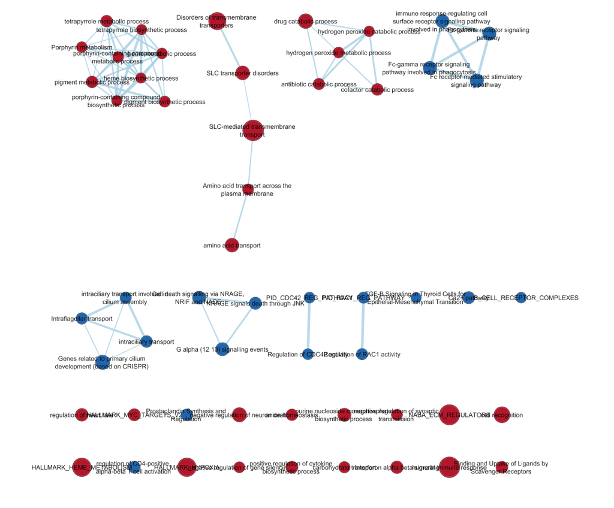

MBD2KO_post:

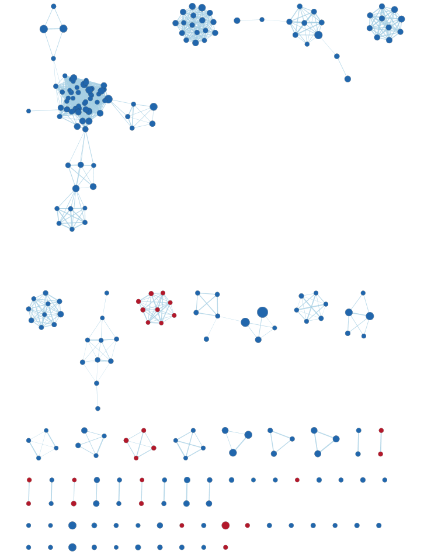

As you can see, the results were more extensive in MBD2KO_post group. As a result, to Cytoscape hid the labels automatically when I zoomed out to take the whole picture.

### Summary of Enrichment Maps

The threshold used to build these two maps were the same. For nodes, FDR q-value cutoff was 0.1, p-value cutoff was 1.0, NES was set to “All”. For edges, Data Set Edges was set to “Automatic”, Cutoff was 0.375, Metric was set to “Jaccard+Overlap Combined”.  
In MBD2KO_pre enrichment map, there were 55 nodes and 64 edges.  
In MBD2KO_post enrichment map, there were 240 nodes and 1408 edges.

## Annotating the network

We annotated the above two networks with Cytoscape.

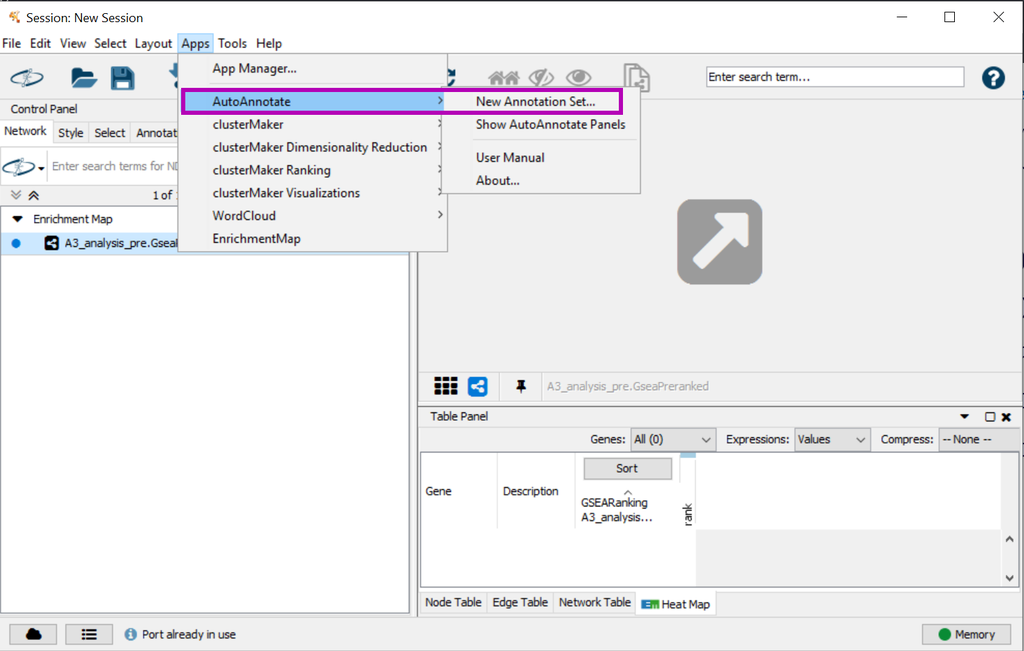

With the default settings, annotations were created.

[figure not shown]

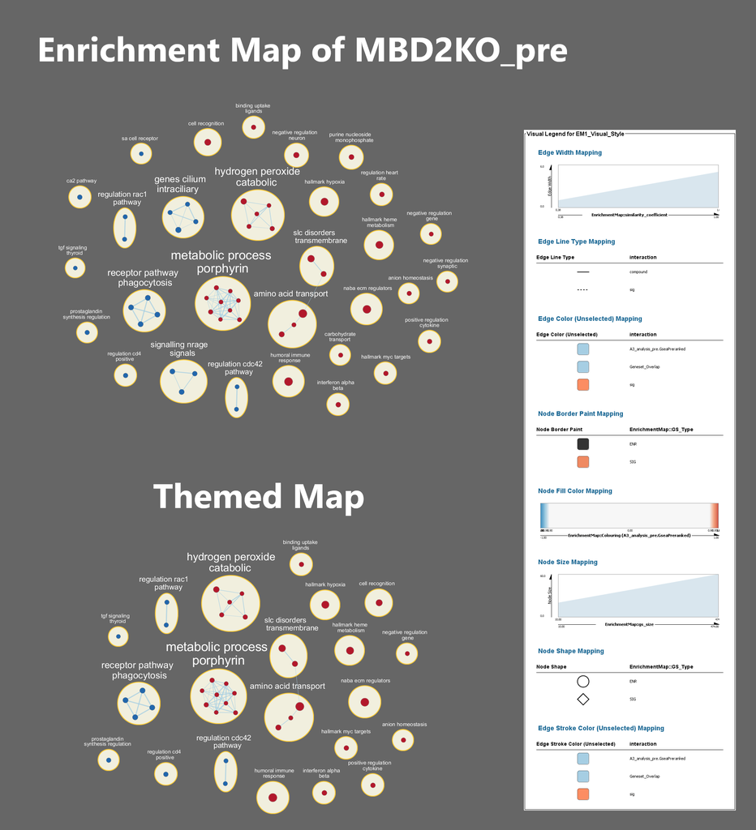

There are not a lot of results in the MBD2KO_pre group. This was expected because from the original paper they found that there were no significant morphological or functional difference in the differentiation of the control and MBD2KO cells.

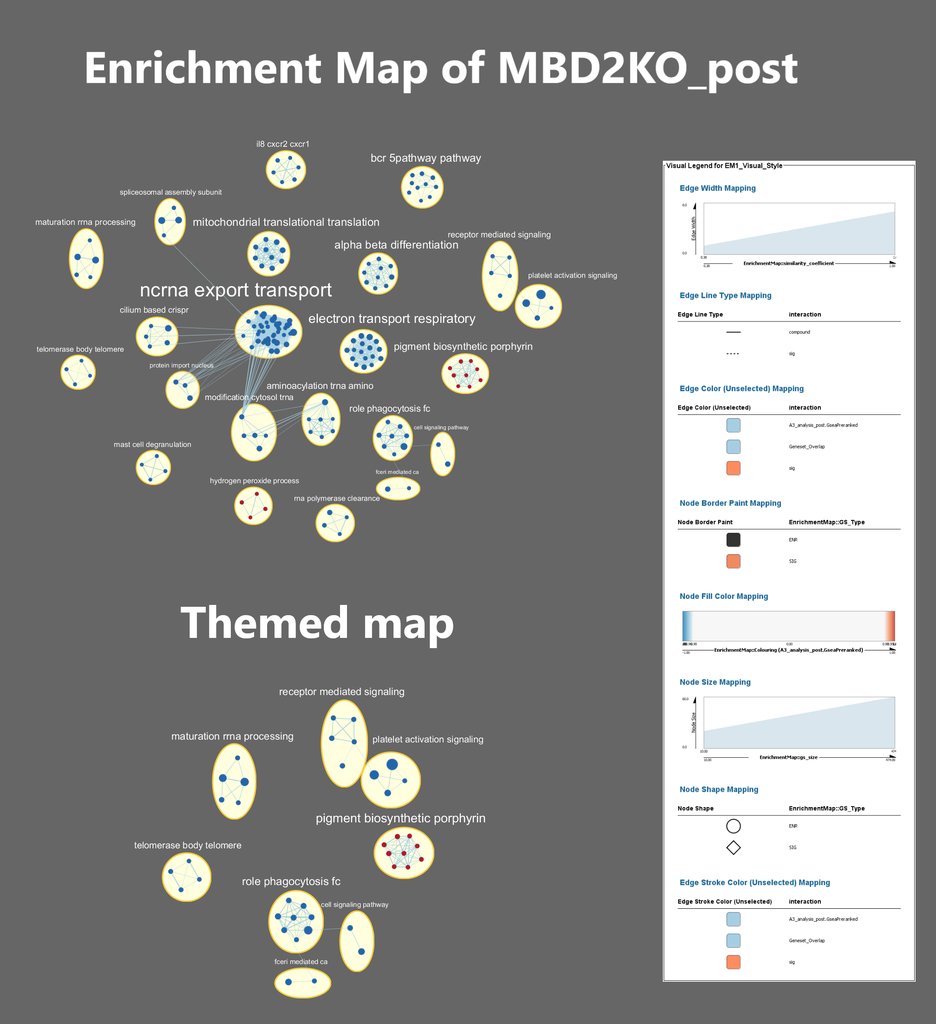

There were more ontology groups showing the characteristics of erythroid cells in the MBD2KO_post analysis. However, these pathway clusters were relatively small, which further confirms the original finding of Yu, et al. (2019). Therefore, similarly to the result of thresholded gene enrichment analysis results, the non-thresholded gene enrichment analysis result support the conclusions discussed in the original paper, as the control (sgSCR) and experimental (MBD2KO) cell types (pre and post) have minimal difference between each other. This supports their claim that MBD2KO has great potential to be a widely helpful in sickle cell amenia patients, as MBD2KO doesn’t have adverse side effects.  
Furthermore, there has been a study done in 2001 by Hendrich, et al, where they found out that MBD2KO mice were viable and fertile, with major deleterious phenotype.<sup>5,6,8</sup>

## Capturing the Dark Matter

Let’s see if there are any genes that we don’t see in our pathway results that could be just as important as the genes that are returned from the analysis. We will load all files necessary to conduct dark matter analysis below. This time, load teh gmt file with package GSA.<sup>8</sup>

```r
# first install the package necessary
if (!requireNamespace("BiocManager")) {
  install.packages("BiocMAnager")
}
if (!requireNamespace("GSA")) {
  install.packages("GSA")
}
# read the geneset file
gmt_file <- file.path("data",
                      "Human_GOBP_AllPathways_no_GO_iea_February_01_2020_symbol.gmt.txt")
capture.output(genesets <- GSA::GSA.read.gmt(gmt_file), file = "gsa_loud.out")

# give proper indices/names
names(genesets$genesets) <- genesets$geneset.names

# load the expression data
expression <- read.table(file = file.path("data", "GSE121992_finalized_normalized_counts.txt"),
                                    header = TRUE, sep = "\t",
                                    stringsAsFactors = FALSE,
                                    check.names = FALSE)

# get all the GSEA directories
gsea_dir_pre <- list.files(path = file.path(getwd(),"data"),
                                 pattern = "\\pre.GseaPreranked")
gsea_dir_post <- list.files(path = file.path(getwd(),"data"),
                                 pattern = "\\post.GseaPreranked")

gsea_dir_pre <- file.path(getwd(), "data", gsea_dir_pre)
gsea_dir_post <- file.path(getwd(), "data", gsea_dir_post)

#get the gsea result files
gsea_results_pre <- list.files(path = gsea_dir_pre,
                                 pattern = "gsea_report_*.*.xls")
gsea_results_post <- list.files(path = gsea_dir_post,
                                 pattern = "gsea_report_*.*.xls")
#there should be 2 gsea results files
enr_file1_pre <- read.table(file.path(gsea_dir_pre,gsea_results_pre[1]),
                        header = TRUE, sep = "\t", quote="\"",
                        stringsAsFactors = FALSE,row.names=1)
enr_file2_pre <- read.table(file.path(gsea_dir_pre,gsea_results_pre[2]),
                        header = TRUE, sep = "\t", quote="\"",
                        stringsAsFactors = FALSE,row.names=1)

enr_file1_post <- read.table(file.path(gsea_dir_post,gsea_results_post[1]),
                        header = TRUE, sep = "\t", quote="\"",
                        stringsAsFactors = FALSE,row.names=1)
enr_file2_post <- read.table(file.path(gsea_dir_post,gsea_results_post[2]),
                        header = TRUE, sep = "\t", quote="\"",
                        stringsAsFactors = FALSE,row.names=1)
```

Now extract all genes in the enrichment results and all genes in the geneset file (GO:BP) to calculate the dark matter from the above files.

```r
# get the genes from the set of enriched pathway
# (no matter what threshold)
all_enr_genesets_pre <- c(rownames(enr_file1_pre), rownames(enr_file2_pre))
all_enr_genesets_post <- c(rownames(enr_file1_post), rownames(enr_file2_post))

genes_enr_gs_pre <- c()
for(i in 1:length(all_enr_genesets_pre)){
  current_geneset <- unlist(genesets$genesets[which(genesets$geneset.names %in% all_enr_genesets_pre[i])])
  genes_enr_gs_pre <- union(genes_enr_gs_pre, current_geneset)
}
genes_enr_gs_post <- c()
for(i in 1:length(all_enr_genesets_post)){
  current_geneset <- unlist(genesets$genesets[which(genesets$geneset.names %in% all_enr_genesets_post[i])])
  genes_enr_gs_post <- union(genes_enr_gs_post, current_geneset)
}

genes_all_gs <- unique(unlist(genesets$genesets))
```

With the loaded datasets, get the set of significant genes that are not annotated to any of the pathways returned in the enrichment analysis.

```r
# all significantly differentially expressed genes
sig_genes_pre <- rownames(ranked_pre)[ranked_pre$PValue <= 0.05]
sig_genes_post <- rownames(ranked_post)[ranked_pre$PValue <= 0.05]
sig_genes_all <- union(sig_genes_pre, sig_genes_post)
sig_genes_all <- setdiff(sig_genes_all, intersect(sig_genes_pre, sig_genes_post))

# all genes annotated to a pathway
genes_enr_gs_all <- union(genes_enr_gs_pre, genes_enr_gs_post)

# dark matter genes
sig_genes_no_annot <- setdiff(sig_genes_all, genes_enr_gs_all)
```

Getting the set of significant genes that are not annotated to any pathways in entire set of pathways used for the analysis:

```r
sig_genes_no_entire <- setdiff(sig_genes_all, genes_all_gs)
```

### Visualization of the Dark Matter with Heatmaps

Let’s visualize the expression of these dark matter genes with heatmaps using R packages ComplexHeatmap and circlize.<sup>9,10</sup>  
First is the heatmap of any significant genes that are not annotated to any of the pathwyas returned in the enrichment analysis.

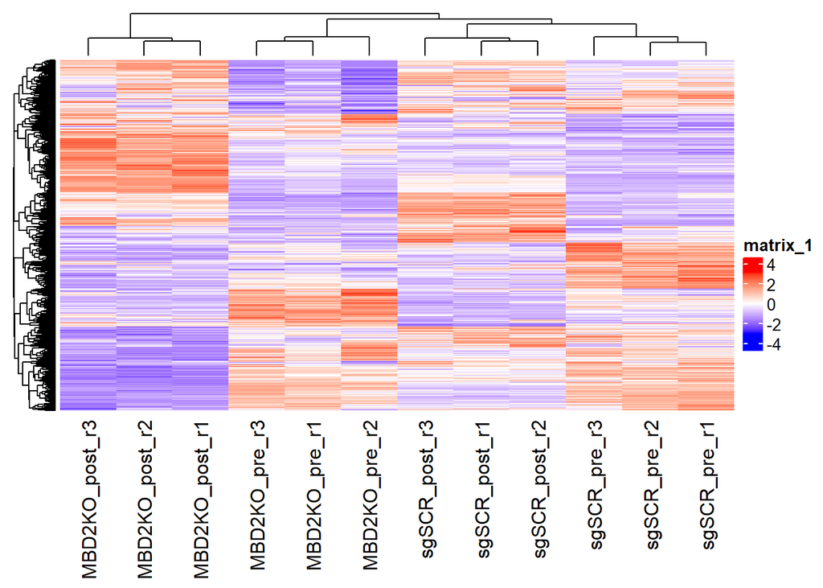

```r
# first load the required packages

if (!requireNamespace("ComplexHeatmap")) {
  BiocManager::install("ComplexHeatmap")
}
if (!requireNamespace("circlize")) {
  install.packages("circlize")
}

# get the expression data of these genes
enrich_dm_heatmap_matrix <- expression[rownames(expression) %in% sig_genes_no_annot,]

# row normalize
enrich_dm_heatmap_matrix <- t(scale(t(enrich_dm_heatmap_matrix)))

# set color scale according to value
if (min(enrich_dm_heatmap_matrix) == 0) {
  heatmap_col = circlize::colorRamp2(c(0, max(enrich_dm_heatmap_matrix)),
                                     c("white", "red"))
} else {
  heatmap_col = circlize::colorRamp2(c(min(enrich_dm_heatmap_matrix), 0,
                                       max(enrich_dm_heatmap_matrix)),
                                     c("blue", "white", "red"))
}

# draw the heatmap
enrich_dark_matter_heatmap <- ComplexHeatmap::Heatmap(as.matrix(enrich_dm_heatmap_matrix),
                                           show_row_dend = TRUE,
                                           show_column_dend = TRUE,
                                           col = heatmap_col,
                                           show_column_names = TRUE,
                                           show_row_names = FALSE,
                                           show_heatmap_legend = TRUE)

enrich_dark_matter_heatmap
```

Now the heatmap of genes that are not annotated to any pathways in the entire set of pathways used for analysis.

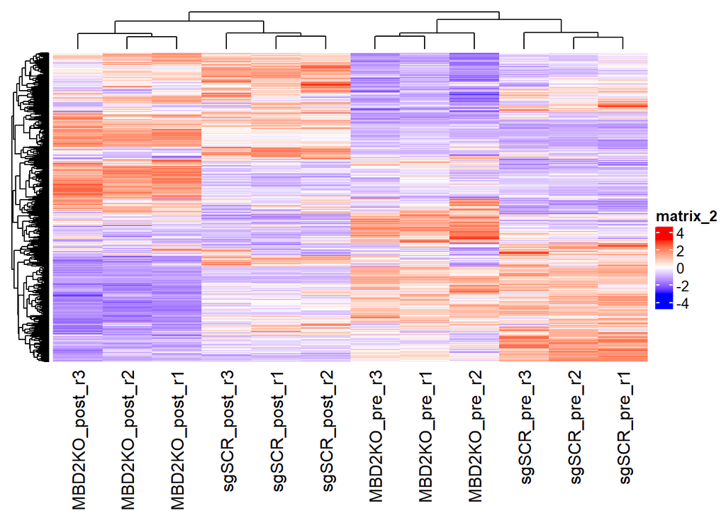

```r
# get the expression data of these genes
entire_dm_heatmap_matrix <- expression[rownames(expression) %in% sig_genes_no_entire,]

# row normalize
entire_dm_heatmap_matrix <- t(scale(t(entire_dm_heatmap_matrix)))

# set color scale according to value
if (min(entire_dm_heatmap_matrix) == 0) {
  heatmap_col = circlize::colorRamp2(c(0, max(entire_dm_heatmap_matrix)),
                                     c("white", "red"))
} else {
  heatmap_col = circlize::colorRamp2(c(min(entire_dm_heatmap_matrix), 0,
                                       max(entire_dm_heatmap_matrix)),
                                     c("blue", "white", "red"))
}

# draw the heatmap
entire_dark_matter_heatmap <- ComplexHeatmap::Heatmap(as.matrix(entire_dm_heatmap_matrix),
                                           show_row_dend = TRUE,
                                           show_column_dend = TRUE,
                                           col = heatmap_col,
                                           show_column_names = TRUE,
                                           show_row_names = FALSE,
                                           show_heatmap_legend = TRUE)

entire_dark_matter_heatmap
```

### References

[1] Yu, X., Azzo, A., Bilinovich, S. M., Li, X., Dozmorov, M., Kurita, R., Nakamura, Y., Williams, D. C., Ginder, G. D. (2019) Disruption of the MBD2-NuRD Complex But Not MBD3-NuRD Induces High Level HbF Expression in Human Adult Erythroid Cells. Haematologica 104:2361-2371; doi:10.3324/haematol.2018.210963

[2] Subramanian, A., Tamayo, P., Mootha, V.K., Mukherjee, S., Ebert, B.L., Gillette, M.A., Paulovich, A., Pomeroy, S.L., Golub, T.R., Landerder, E.S., Mesirov, J.P. (2005) Gene set enrichment analysis: a knowledge-based approach for interpreting genome-wide expression profiles. Proc Natl Acad Sci USA. 102(43):15545-50.

[3] Yaari G, Bolen C, Thakar J, Kleinstein S (2013). “Quantitative set analysis for gene expression: a method to quantify gene set differential expression including gene-gene correlations.” Nucleic Acids Res..

[4] Merico, D., Isserlin, R., Stueker, O., Emili, A., Bader, G.D. (2010) Enrichment Map: A network based method for gene-set enrichment visualization and interpretation. PLoS One. 5(11):e13984.

[5] McCarthy DJ, Chen Y and Smyth GK (2012). Differential expression analysis of multifactor RNA-Seq experiments with respect to biological variation. Nucleic Acids Research 40, 4288-4297

[6] Hendrich, B., Guy, J., Ramsahoye, B., Wilson, V. A., & Bird, A. (2001). Closely related proteins MBD2 and MBD3 play distinctive but interacting roles in mouse development. Genes & development, 15(6), 710-723. https://doi.org/10.1101/gad.194101

[7] Ginder, G.D. (2015) Epigenetic regulation of fetal globin gene expression in adult erythroid cells. Translational Research. 165(1):115-125.

[8] Subramanian, A. and Tamayo, P. Mootha, V. K. and Mukherjee, S. and Ebert, B. L. and Gillette, M. A. and Paulovich, A. and Pomeroy, S. L. and Golub, T. R. and Lander, E. S. and Mesirov, J. P. (2005). A knowledge-based approach for interpreting genome-wide expression profiles. PNAS. 102, pg 15545-15550.

[9] Gu Z, Eils R, Schlesner M (2016). “Complex heatmaps reveal patterns and correlations in multidimensional genomic data.” Bioinformatics.

[10] Gu Z, Gu L, Eils R, Schlesner M, Brors B (2014). “circlize implements and enhances circular visualization in R.” Bioinformatics, 30, 2811-2812.